# Logical regression analysis of the IODS project

*This section describes the steps taken to perform logical regression analysis of data obtained for the Machine Learning repository*

First, let me begin by reading the data for this analysis into R from online.

```r
# install.packages("ggplot2")
#library(ggplot2)

# Reading the data from web address
data <- "https://github.com/rsund/IODS-project/raw/master/data/alc.csv"

# read the math class questionaire data into memory
math_por <- read.table(data, sep = "," , header=TRUE)

# We can have glimpse of the data
str(math_por)
```

```
## 'data.frame':    370 obs. of  51 variables:
##  $ school    : chr  "GP" "GP" "GP" "GP" ...
##  $ sex       : chr  "F" "F" "F" "F" ...
##  $ age       : int  15 15 15 15 15 15 15 15 15 15 ...
##  $ address   : chr  "R" "R" "R" "R" ...
##  $ famsize   : chr  "GT3" "GT3" "GT3" "GT3" ...
##  $ Pstatus   : chr  "T" "T" "T" "T" ...
##  $ Medu      : int  1 1 2 2 3 3 3 2 3 3 ...
##  $ Fedu      : int  1 1 2 4 3 4 4 2 1 3 ...
##  $ Mjob      : chr  "at_home" "other" "at_home" "services" ...
##  $ Fjob      : chr  "other" "other" "other" "health" ...
##  $ reason    : chr  "home" "reputation" "reputation" "course" ...
##  $ guardian  : chr  "mother" "mother" "mother" "mother" ...
##  $ traveltime: int  2 1 1 1 2 1 2 2 2 1 ...
##  $ studytime : int  4 2 1 3 3 3 3 2 4 4 ...
```

[output cut: 37 more lines]

```r
dim(math_por)
```

```
## [1] 370  51
```

```r
colnames(math_por)
```

```
##  [1] "school"     "sex"        "age"        "address"    "famsize"
##  [6] "Pstatus"    "Medu"       "Fedu"       "Mjob"       "Fjob"
## [11] "reason"     "guardian"   "traveltime" "studytime"  "schoolsup"
## [16] "famsup"     "activities" "nursery"    "higher"     "internet"
## [21] "romantic"   "famrel"     "freetime"   "goout"      "Dalc"
## [26] "Walc"       "health"     "n"          "id.p"       "id.m"
## [31] "failures"   "paid"       "absences"   "G1"         "G2"
## [36] "G3"         "failures.p" "paid.p"     "absences.p" "G1.p"
## [41] "G2.p"       "G3.p"       "failures.m" "paid.m"     "absences.m"
## [46] "G1.m"       "G2.m"       "G3.m"       "alc_use"    "high_use"
## [51] "cid"
```

The data contain 370 observations and 51 variables. The data was read from the online ML repository, which is a combined students data from the UCI.

```r
# Let me print the heading to see the nature of the data

head(math_por)
```

```
##   school sex age address famsize Pstatus Medu Fedu     Mjob     Fjob     reason
## 1     GP   F  15       R     GT3       T    1    1  at_home    other       home
## 2     GP   F  15       R     GT3       T    1    1    other    other reputation
## 3     GP   F  15       R     GT3       T    2    2  at_home    other reputation
## 4     GP   F  15       R     GT3       T    2    4 services   health     course
## 5     GP   F  15       R     GT3       T    3    3 services services reputation
## 6     GP   F  15       R     GT3       T    3    4 services   health     course
##   guardian traveltime studytime schoolsup famsup activities nursery higher
## 1   mother          2         4       yes    yes        yes     yes    yes
## 2   mother          1         2       yes    yes         no      no    yes
## 3   mother          1         1       yes    yes        yes     yes    yes
## 4   mother          1         3       yes    yes        yes     yes    yes
## 5    other          2         3        no    yes        yes     yes    yes
## 6   mother          1         3       yes    yes        yes     yes    yes
##   internet romantic famrel freetime goout Dalc Walc health n id.p id.m failures
```

[output cut: 20 more lines]

We observe that some new variables different from the original data collected in the separate datasets were added to the combined data. These new variables shows a suffix “.p” or “.m” indicating “por_data” and “math_data” respectively. For example, the “id.p” and “id.m”

#### Variables selected to conducted anaylsis

I am selecting the following variables: 1. Sex 2. high_use 2. G3 (students final grade) 3. famrel (students quality of family relationship)

Based on my variable selection, the following are my hypothesis:

**H1** There is a significant difference of alcohol consuption in male and females.

**H2** Alcohol consumption can affect the quality of students’ family relationship.

**H3** Alcohol consumption can have a significant impact of on students’ final grades.

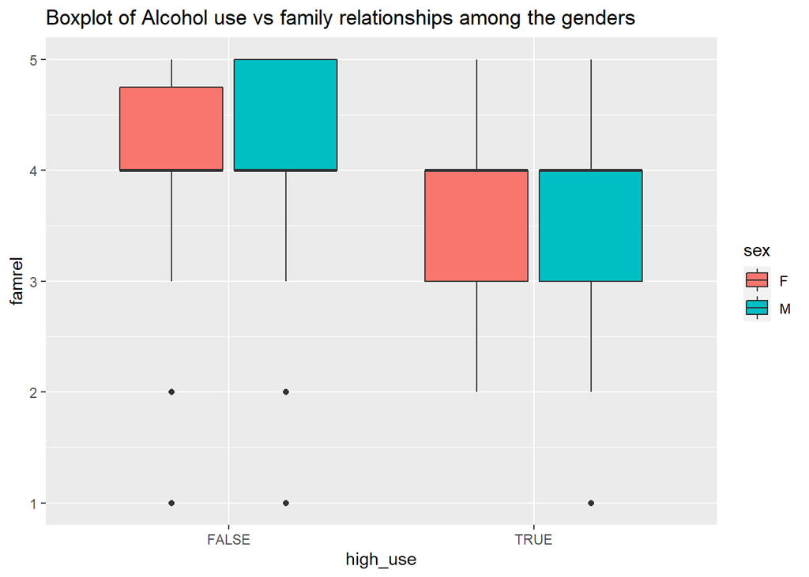

```r
#This section, I am going to be explore my four variables by plotting graphs.
library(dplyr)
library(ggplot2)
ggplot(data=math_por, aes(x=high_use, y=famrel, fill=sex))+ geom_boxplot() +
  labs(title="Boxplot of Alcohol use vs family relationships among the genders")
```

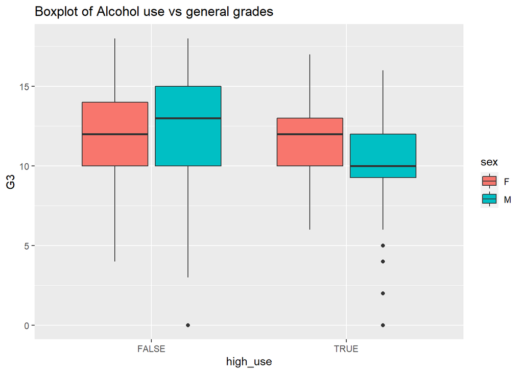

```r
# Here, I am trying to plot the graph of high_use of alcohol against sex and grades
ggplot(data=math_por, aes(x=high_use, y=G3, fill=sex))+ geom_boxplot() +
  labs(title="Boxplot of Alcohol use vs general grades")
```

### Logistics regression analysis here!

```r
# find the model with glm() with variables alcohol use vs students' grades, family relationship, and sex
m <- glm(high_use ~ G3 + famrel + sex, data = math_por, family = "binomial")

# Summary of the model is printed below
m
```

```
##
## Call:  glm(formula = high_use ~ G3 + famrel + sex, family = "binomial",
##     data = math_por)
##
## Coefficients:
## (Intercept)           G3       famrel         sexM
##     0.89134     -0.08851     -0.32041      0.98858
##
## Degrees of Freedom: 369 Total (i.e. Null);  366 Residual
## Null Deviance:       452
## Residual Deviance: 423.1     AIC: 431.1
```

```r
#Coefficient of the model is printed here
coef(m)
```

```
## (Intercept)          G3      famrel        sexM
##  0.89133738 -0.08851078 -0.32040808  0.98858435
```